# 4. Dimensionality reduction techniques

*This file describes the work and results of the fifth week a. k. a. “Dimensionality reduction techniques” of the IDOS2023 course.*

### 4.1 Graphical and numerical overview of data

The ‘human’ data set comes from the United Nations Development Programme a d uses the HDI (Human Development Index) to assess the development on a country according to citizen attributes, not only economic growth (more information here: https://hdr.undp.org/data-center/human-development-index#/indicies/HDI).

The data shows that the mean life expectancy at birth (*Life.Exp*) varies a lot, with a minimum of 49 years, a median of 74 years, and a maximum of 83 years, respectively (see summary below). A high percentage of the population enjoys secondary education, both Female and Male (*Edu2.FM*). This is also well represented with the expected years of education (*Edu.Exp*) being around 13 years. The labour force participation rate (*Labo.FM*) shows a median of 75%. The representation of women in the parliament varies from none (min = 0) to a maximum of 57%. On average, every fifth member of a parliament is female.

```r
# access all packages needed in this chunk
library(dplyr)
library(readr)
library(tibble)
library(GGally)
library(corrplot)

# load in data
human <- read.csv(file='/home/ntriches/github_iods2023/IODS23/data/human.csv', header=TRUE)

# move the country names to rownames
human_country_as_row <- column_to_rownames(human, "Country")

# summary
summary(human_country_as_row)
```

```
##     Edu2.FM          Labo.FM          Edu.Exp         Life.Exp
##  Min.   :0.1717   Min.   :0.1857   Min.   : 5.40   Min.   :49.00
##  1st Qu.:0.7264   1st Qu.:0.5984   1st Qu.:11.25   1st Qu.:66.30
##  Median :0.9375   Median :0.7535   Median :13.50   Median :74.20
##  Mean   :0.8529   Mean   :0.7074   Mean   :13.18   Mean   :71.65
##  3rd Qu.:0.9968   3rd Qu.:0.8535   3rd Qu.:15.20   3rd Qu.:77.25
##  Max.   :1.4967   Max.   :1.0380   Max.   :20.20   Max.   :83.50
##       GNI            Mat.Mor         Ado.Birth         Parli.F
##  Min.   :   581   Min.   :   1.0   Min.   :  0.60   Min.   : 0.00
##  1st Qu.:  4198   1st Qu.:  11.5   1st Qu.: 12.65   1st Qu.:12.40
##  Median : 12040   Median :  49.0   Median : 33.60   Median :19.30
##  Mean   : 17628   Mean   : 149.1   Mean   : 47.16   Mean   :20.91
##  3rd Qu.: 24512   3rd Qu.: 190.0   3rd Qu.: 71.95   3rd Qu.:27.95
##  Max.   :123124   Max.   :1100.0   Max.   :204.80   Max.   :57.50
```

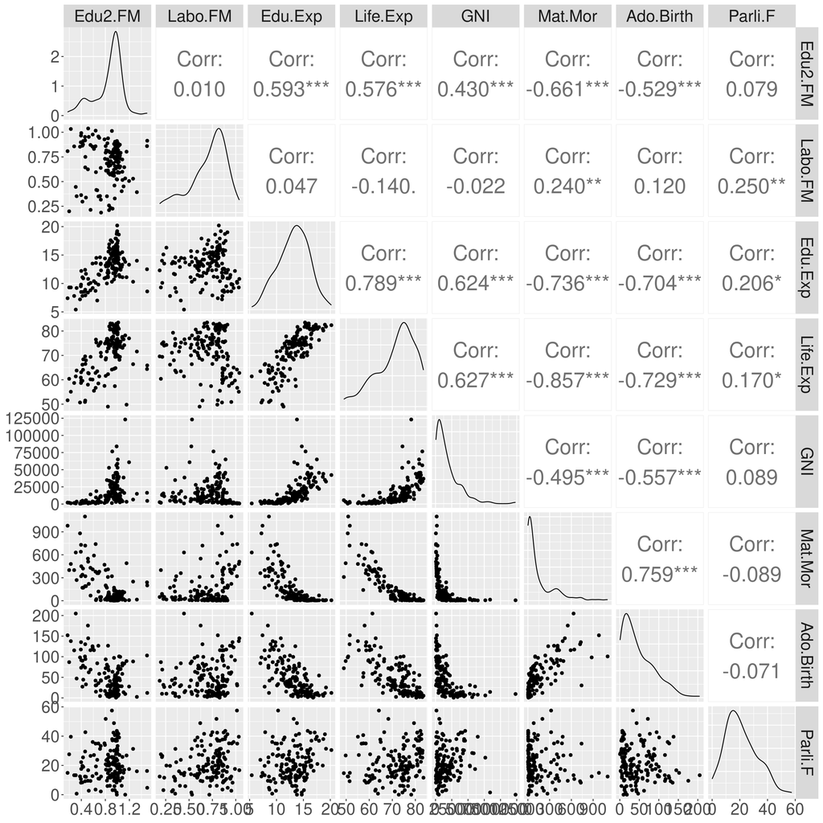

```r
# visualize the 'human_' variables
plot_corr_humans <- human_country_as_row %>%
  ggpairs(progress = FALSE,
        upper = list(continuous = wrap("cor", size = 9)))
# plot corr_humans and adjust font size
plot_corr_humans +
  theme(axis.text  = element_text(size = 20),
        strip.text = element_text(size = 20))
```

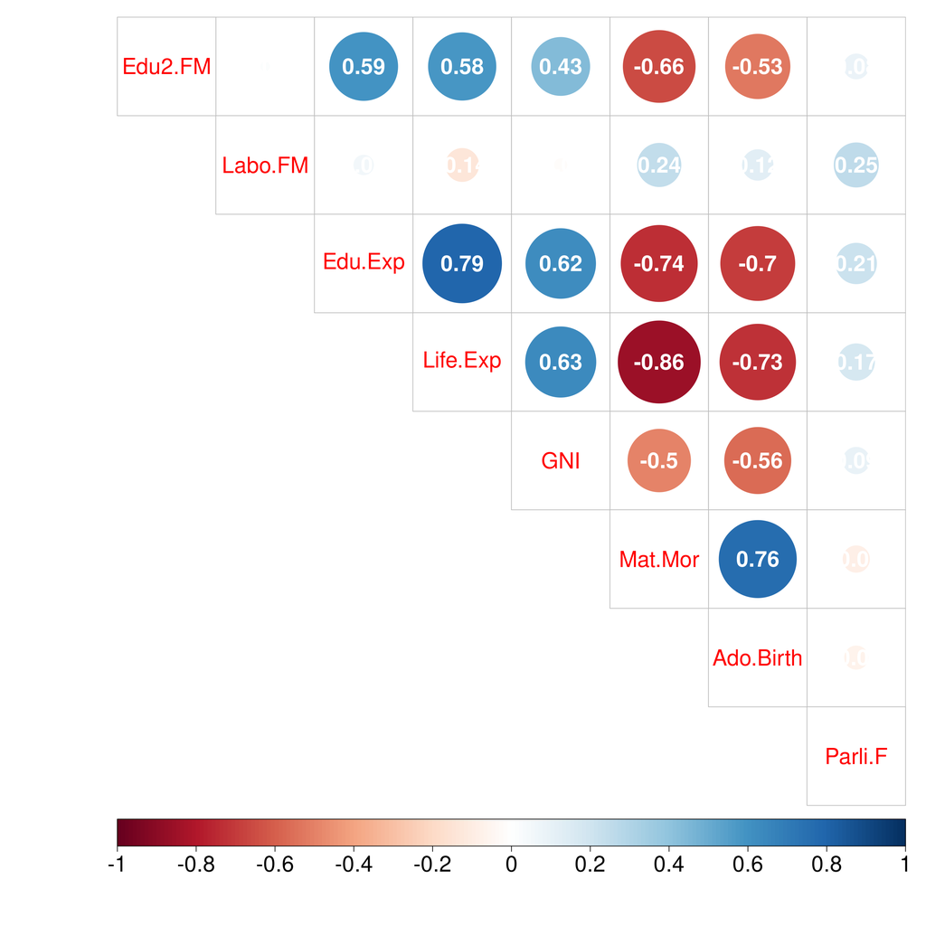

```r
# compute the correlation matrix and visualize it with corrplot
cor_matrix <- cor(human_country_as_row) %>%
  round(digits = 2)

# visualise the correlation matrix
# cl.cex = change font size of number-labels in colour-legend
# addCoef.col = add correlation value to circle, number.cex = adjust the font size of the number
plot_cor_matrix <- cor_matrix %>%
  corrplot(method="circle", addCoef.col = 0.5, type = "upper", cl.pos = "b", tl.pos = "d", tl.cex = 2,
           number.cex = 2, cl.cex = 2)
```

Many of the variables show some correlation (see above). From the correlation matrix, we can see that *Life.Exp* and the Maternal mortality ratio (*Mat.Mor*) have a strong relative correlation (-0.86). Also the Expected years of schooling (*Edu.Exp*) and *Mat.Mor*, *Edu.Exp* and Adolescent birth rate (*Ado.Birth*), and *Life.Exp* and *Ado.Birth* are negatively correlated with -0.74, -0.7, and -0.73, respectively. On the other hand, *Edu.Exp* and *Life.Exp*, and *Mat.Mor* and *Ado.Birth* and strongly positively correlated witz 0.79 and 0.76, respectively. According to the black-and-white plots from ggpairs, all these relationships are significant. Looking at the distribution of our variables, we can see that *Edu.Exp* is the only normally distributed variable. Gross National Income per capita (*GNI*) and *Mat.Mor* are strongly right skewed, and so are *Ado.Birth* and *Parli.F*, although to a lesser extent. Both *Labo.FM* and *Life.Exp* are left skewed.